# R Notebook

4. Erstellen Sie eine Analyse, bei der nicht die Bücher, sondern die Autoren in den Transaktionen enthalten sind
5. Fällt Ihnen etwas in der Datenqualität auf?

Es werden, im Verlgeich zu den Buchtiteln, wenig Regeln gefunden. Selbst den Confidence Wert weiter herunter zu setzen, bringt keine zusätzlichen Assoziationen. Ich vermute es liegt an den verschiedenen Arten, wie die Namen der Autoren geschrieben wurden, ob Namen abgekürzt wurden, oder andere Autoren beteiligt waren und so z.B. “et al” am Namen hängt

6. Wie könnte man das mit regulären Ausdrücken beheben?

Die Namen müssen noch weiter Bereinigt werden. Sonderzeichen, auch Klammern und Anführungszeichen, Abkürzungen und Titel entfernt werden.

7. Wie kann man nun noch sicherstellen, dass nur die Autoren weiterempfohlen werden, deren Bücher man auch (mehrheitlich) gut fand?

Die einfachste Methode wäre, den Dataframe nach Bewertungen zu filtern, die über einen bestimmten Wert sind. So wie ich es bei den Buchbewertungen einer früheren Sitzung getan habe: best_books <- filter(books_w_ratings, `Book-Rating`==10)

8. Welche anderen Features wären sinnvoll?

Es wäre Sinnvoll die User in Altersgruppen einzusortieren(z.B. User über 60 fanden noch diese Bücher gut), oder je nach Region die Location anders zu gewichten, damit lokale Autoren mit in die Regeln aufgenommen werden, die im großen Datensatz untergehen würden.

Splitten mit User und Autoren

```r
gesplittet2 <- split(books$`Book-Author` ,books$`User-ID`)
```

Neuer DF zum anschauen

```r
newDF <- books %>%
  select(`Book-Author`,`User-ID`)
```

Zu einer Transaktion machen

```r
trans2 <- as(gesplittet2, "transactions")
```

```
removing duplicated items in transactions
```

Regeln bilden

```r
trans2.rules <- apriori(trans2, parameter=list(supp=0.01, conf=0.01, target="rules"))
```

```
Apriori

Parameter specification:
```

|  | confidence | minval | smax | arem | aval | originalSupport | maxtime | support | minlen | maxlen | target | ext |
| --- | --- | --- | --- | --- | --- | --- | --- | --- | --- | --- | --- | --- |
|  | 0.01 | 0.1 | 1 | none | FALSE | TRUE | 5 | 0.01 | 1 | 10 | rules | TRUE |

```
Algorithmic control:
```

|  | filter | tree | heap | memopt | load | sort | verbose |
| --- | --- | --- | --- | --- | --- | --- | --- |
|  | 0.1 | TRUE | TRUE | FALSE | TRUE | 2 | TRUE |

```
Absolute minimum support count: 920

set item appearances ...[0 item(s)] done [0.00s].
set transactions ...[98867 item(s), 92099 transaction(s)] done [0.37s].
sorting and recoding items ... [52 item(s)] done [0.01s].
creating transaction tree ... done [0.01s].
checking subsets of size 1 2 done [0.00s].
writing ... [58 rule(s)] done [0.00s].
creating S4 object  ... done [0.01s].
```

inspezieren

```r
(head(inspect(subset(trans2.rules)), 10))
```

|  | lhs |  | rhs | support | confidence | coverage | lift | count |
| --- | --- | --- | --- | --- | --- | --- | --- | --- |
| [1] | {} | => | {nick hornby} | 0.01070587 | 0.01070587 | 1.00000000 | 1.000000 | 986 |
| [2] | {} | => | {isabel allende} | 0.01052129 | 0.01052129 | 1.00000000 | 1.000000 | 969 |
| [3] | {} | => | {neil gaiman} | 0.01067330 | 0.01067330 | 1.00000000 | 1.000000 | 983 |
| [4] | {} | => | {douglas adams} | 0.01146592 | 0.01146592 | 1.00000000 | 1.000000 | 1056 |
| [5] | {} | => | {patricia cornwell} | 0.01058643 | 0.01058643 | 1.00000000 | 1.000000 | 975 |
| [6] | {} | => | {william shakespeare} | 0.01083617 | 0.01083617 | 1.00000000 | 1.000000 | 998 |
| [7] | {} | => | {jane austen} | 0.01190024 | 0.01190024 | 1.00000000 | 1.000000 | 1096 |
| [8] | {} | => | {david baldacci} | 0.01112933 | 0.01112933 | 1.00000000 | 1.000000 | 1025 |
| [9] | {} | => | {dean koontz} | 0.01150935 | 0.01150935 | 1.00000000 | 1.000000 | 1060 |
| [10] | {} | => | {frank mccourt} | 0.01263857 | 0.01263857 | 1.00000000 | 1.000000 | 1164 |

[output cut: 48 more lines]

|  | lhs |  | rhs | support | confidence | coverage | lift | count |
| --- | --- | --- | --- | --- | --- | --- | --- | --- |
| [1] | {} | => | {nick hornby} | 0.01070587 | 0.01070587 | 1 | 1 | 986 |
| [2] | {} | => | {isabel allende} | 0.01052129 | 0.01052129 | 1 | 1 | 969 |
| [3] | {} | => | {neil gaiman} | 0.01067330 | 0.01067330 | 1 | 1 | 983 |
| [4] | {} | => | {douglas adams} | 0.01146592 | 0.01146592 | 1 | 1 | 1056 |
| [5] | {} | => | {patricia cornwell} | 0.01058643 | 0.01058643 | 1 | 1 | 975 |
| [6] | {} | => | {william shakespeare} | 0.01083617 | 0.01083617 | 1 | 1 | 998 |
| [7] | {} | => | {jane austen} | 0.01190024 | 0.01190024 | 1 | 1 | 1096 |
| [8] | {} | => | {david baldacci} | 0.01112933 | 0.01112933 | 1 | 1 | 1025 |
| [9] | {} | => | {dean koontz} | 0.01150935 | 0.01150935 | 1 | 1 | 1060 |
| [10] | {} | => | {frank mccourt} | 0.01263857 | 0.01263857 | 1 | 1 | 1164 |

Für die Visualisierung nach Lift aussuchen

```r
subrules2 <- head(trans2.rules, n = 10, by = "lift")
```

Visualisierung

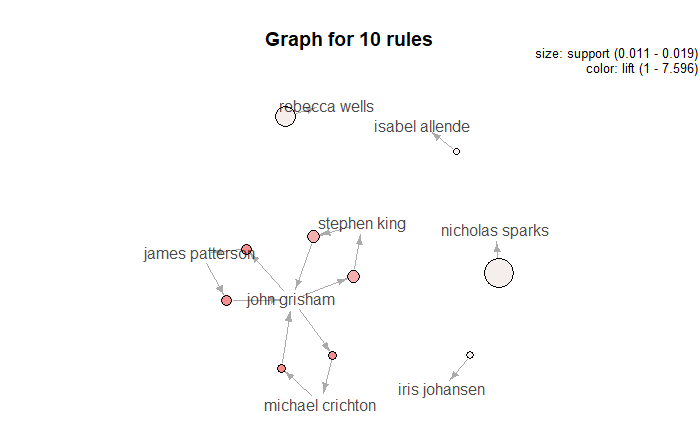

```r
plot(subrules2, method = "graph")
```